# Stolen Childhood; Not a Gender Activism Problem

Author

Debtanu Chakraborty

Published

April 25, 2025

# Stolen Childhood; Not a Gender Activism problem

Children those between the ages 5-17 years engaged in any economic activity or household chore are counted as child labourer . We try to visualise the rates of children engaged in child labour across the globe…

### Global Distribution of Child Labour (Total %)

This map shows the distribution of child labour globally. Brighter countries have higher child labour rates. Countries with missing data are shown in grey.

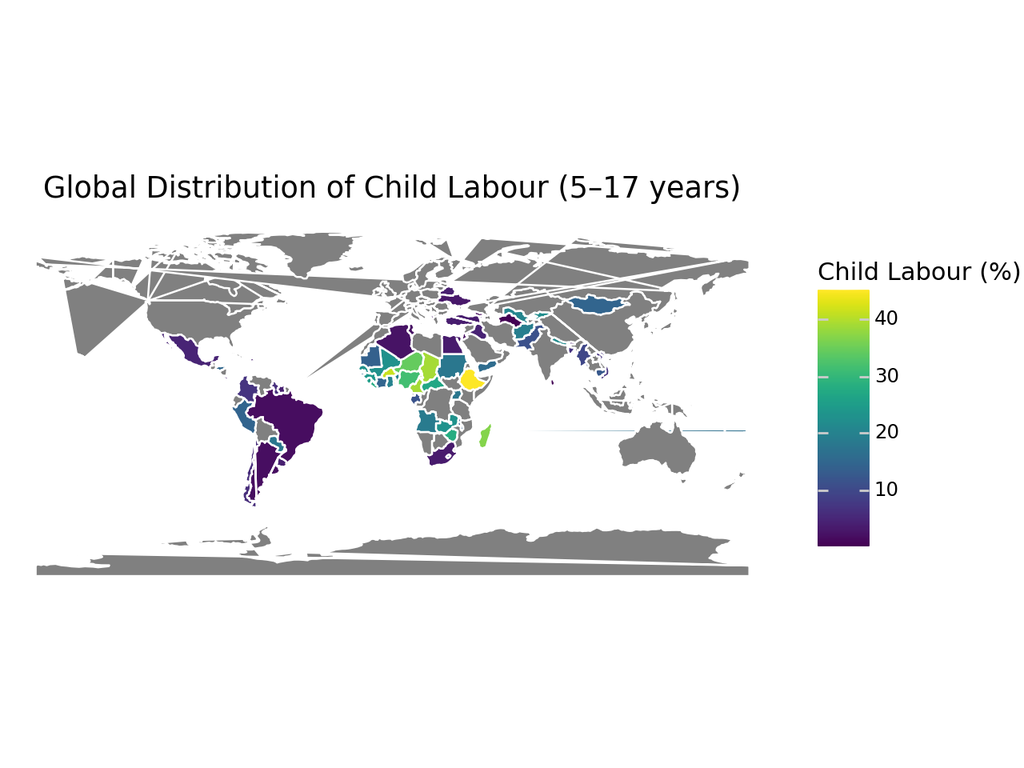

```python
import polars as pl
import pandas as pd
import geopandas as gpd
from plotnine import *

# 1. Loading UNICEF data from my Google Drive
csv_url = "https://docs.google.com/spreadsheets/d/1vB5XSP-FoSzD56Gnp51fGyLduLE5M5m_/export?format=csv&gid=326492224"
unicef_indicator_1 = pl.read_csv(csv_url)

# 2. Keeping only 'Total' sex
child_labour_total = (
    unicef_indicator_1
    .filter(pl.col("sex") == "Total")
    .group_by("country")
    .agg(pl.col("obs_value").mean().alias("mean_labour"))
)

# 3. Loading World shapefile
world = gpd.read_file("https://raw.githubusercontent.com/nvkelso/natural-earth-vector/master/geojson/ne_110m_admin_0_countries.geojson")

# 4. Merging UNICEF data with world map
world = world.merge(child_labour_total.to_pandas(), left_on="ADMIN", right_on="country", how="left")

# 5. Exploinge MultiPolygons to Polygons
world = world.explode(index_parts=False)

# 6. Converting geometry to x, y for plotnine manually
world['x'] = world.geometry.apply(lambda geom: geom.exterior.coords.xy[0] if geom and hasattr(geom, 'exterior') else None)
world['y'] = world.geometry.apply(lambda geom: geom.exterior.coords.xy[1] if geom and hasattr(geom, 'exterior') else None)

# 7. Flattening x and y into a DataFrame
rows = []
for idx, row in world.iterrows():
    if row['x'] is not None:
        for xi, yi in zip(row['x'], row['y']):
            rows.append({
                'long': xi,
                'lat': yi,
                'mean_labour': row['mean_labour'],
                'group': row['ADMIN']
            })
world_df = pd.DataFrame(rows)

# 8. Plotting using plotnine
(
    ggplot(world_df)
    + aes(x='long', y='lat', group='group', fill='mean_labour')
    + geom_polygon(color='white')
    + coord_fixed()
    + scale_fill_continuous(name="Child Labour (%)", na_value="grey")
    + theme_void()
    + labs(title="Global Distribution of Child Labour (5–17 years)")
)
```

### Enhanced Map of Global Distribution (Total %)

This map drawn with *Matplotlib* rather than *Plotnine* shows the distribution of child labour globally. Darker countries have higher child labour rates. Like the last map, countries with missing data are shown in grey but do not get distorted by their polygonal shapes.

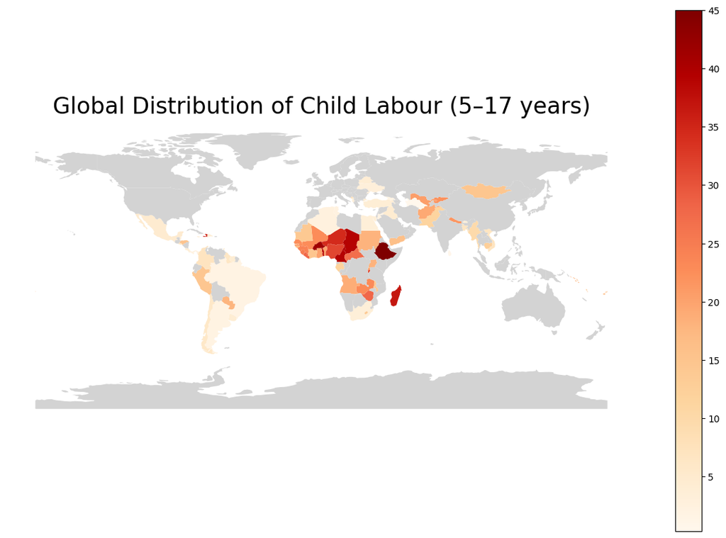

```python
import polars as pl
import pandas as pd
import geopandas as gpd
import matplotlib.pyplot as plt

# 1. Loading UNICEF data from Google Sheets
csv_url = "https://docs.google.com/spreadsheets/d/1vB5XSP-FoSzD56Gnp51fGyLduLE5M5m_/export?format=csv&gid=326492224"
unicef_indicator_1 = pl.read_csv(csv_url)

# 2. Keeping only 'Total' sex and calculating the mean labour
child_labour_total = (
    unicef_indicator_1
    .filter(pl.col("sex") == "Total")
    .group_by("country")
    .agg(pl.col("obs_value").mean().alias("mean_labour"))
)

# 3. Loading World shapefile
world = gpd.read_file("https://raw.githubusercontent.com/nvkelso/natural-earth-vector/master/geojson/ne_110m_admin_0_countries.geojson")

# 4. Merging UNICEF data with world map
world = world.merge(child_labour_total.to_pandas(), left_on="ADMIN", right_on="country", how="left")

# 5. Plotting using geopandas
fig, ax = plt.subplots(1, 1, figsize=(15, 10))
world.plot(column='mean_labour', cmap='OrRd', legend=True, missing_kwds={'color': 'lightgrey', 'label': 'No Data'}, ax=ax)
ax.set_title("Global Distribution of Child Labour (5–17 years)", fontsize=24)
ax.set_axis_off()
plt.show()
```

### Child Labour by Gender across Countries

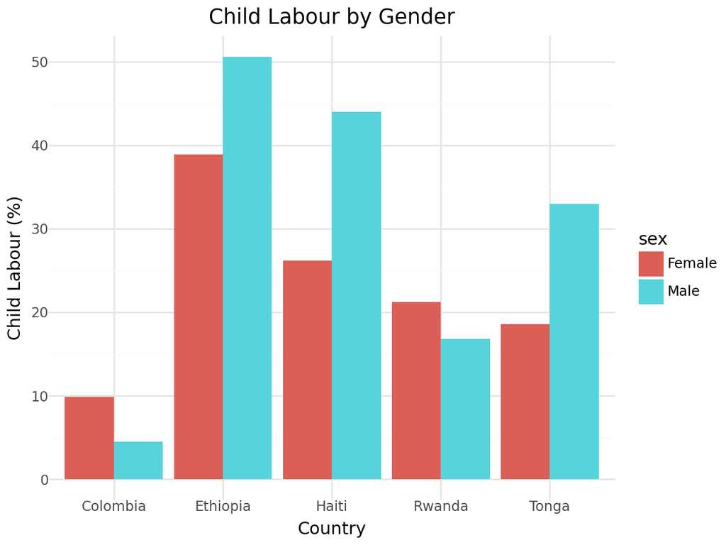

```python
import polars as pl
from plotnine import *

# Loading UNICEF data again (fresh)
unicef_indicator_1 = pl.read_csv("https://docs.google.com/spreadsheets/d/1vB5XSP-FoSzD56Gnp51fGyLduLE5M5m_/export?format=csv&gid=326492224")

# Filtering Male and Female
gender_gap = (
    unicef_indicator_1
    .filter(pl.col("sex").is_in(["Male", "Female"]))
    .filter(pl.col("country").is_in(["Haiti", "Tonga", "Ethiopia", "Rwanda", "Colombia"]))
    .group_by(["country", "sex"])
    .agg(pl.col("obs_value").mean().alias("mean_labour"))
)

# Plotting
(
    ggplot(gender_gap.to_pandas())
    + aes(x="country", y="mean_labour", fill="sex")
    + geom_bar(stat="identity", position="dodge")
    + labs(x="Country", y="Child Labour (%)", title="Child Labour by Gender")
    + theme_minimal()
)
```